# Exploratory analysis Capstone Project

## Barplots and Words clouds

We see that the most used words are “empty” I make barplots and clouds by omitting these words

```r
 # Remove english common stopwords
  newscorpus2 <- tm_map(newscorpus, removeWords, stopwords(kind='en'))
  blogscorpus2 <- tm_map(blogscorpus, removeWords, stopwords(kind='en'))
  twittercorpus2 <- tm_map(twittercorpus, removeWords, stopwords(kind='en'))
# barplot most used words in NEWS
  dtm2n <- TermDocumentMatrix(newscorpus2)
  m2n<- as.matrix(dtm2n)
  v2n <- sort(rowSums(m2n),decreasing=TRUE)
  d2n <- data.frame(word = names(v2n),freq=v2n)
  kable(head(d2n, 10))
```

|  | word | freq |
| --- | --- | --- |
| said | said | 1869 |
| will | will | 809 |
| one | one | 641 |
| new | new | 527 |
| also | also | 454 |
| can | can | 448 |
| first | first | 447 |
| year | year | 434 |
| just | just | 423 |
| two | two | 413 |

```r
# barplot most used words in BLOGS
  dtm2b <- TermDocumentMatrix(blogscorpus2)
  dtm2b <- removeSparseTerms(dtm2b, sparse = 0.99)
  m2b <- as.matrix(dtm2b)
  v2b <- sort(rowSums(m2b),decreasing=TRUE)
  d2b <- data.frame(word = names(v2b),freq=v2b)
  kable(head(d2b, 10))
```

|  | word | freq |
| --- | --- | --- |
| one | one | 12443 |
| will | will | 11260 |
| can | can | 10003 |
| like | like | 9839 |
| just | just | 9820 |
| time | time | 8785 |
| get | get | 7209 |
| ’s | ’s | 7101 |
| know | know | 5894 |
| people | people | 5840 |

```r
 # barplot most used words in TWITTER
  dtm2t <- TermDocumentMatrix(twittercorpus2)
          dtm2t <- removeSparseTerms(dtm2t, sparse = 0.99)
  m2t <- as.matrix(dtm2t)
  v2t <- sort(rowSums(m2t),decreasing=TRUE)
  d2t <- data.frame(word = names(v2t),freq=v2t)
  kable(head(d2t, 10))
```

|  | word | freq |
| --- | --- | --- |
| just | just | 15016 |
| like | like | 11992 |
| get | get | 11213 |
| love | love | 10646 |
| good | good | 10061 |
| will | will | 9546 |
| day | day | 9067 |
| dont | dont | 9060 |
| can | can | 9020 |
| thanks | thanks | 8974 |

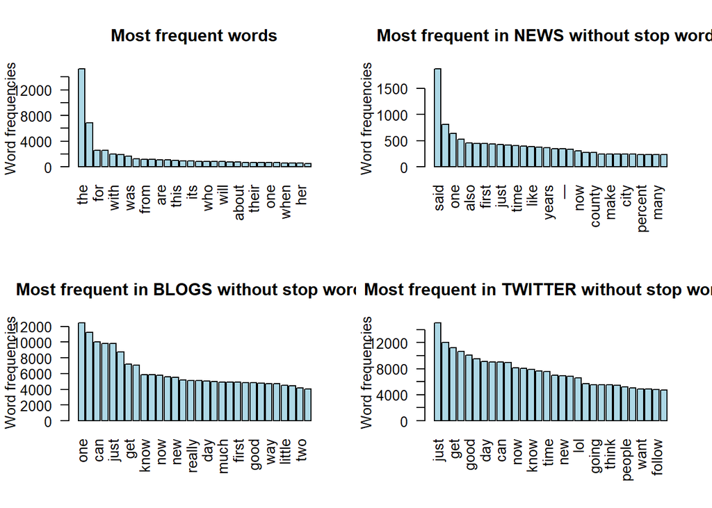

```r
  # 4 plots
  par(mfrow = c(2,2))

  p1<- barplot(d[1:30,]$freq, las = 2, names.arg = d[1:30,]$word,
               col ="lightblue", main ="Most frequent words",
               ylab = "Word frequencies")

  p2<- barplot(d2n[1:30,]$freq, las = 2, names.arg = d2n[1:30,]$word,
               col ="lightblue", main ="Most frequent in NEWS without stop words",
               ylab = "Word frequencies")

  p3<-barplot(d2b[1:30,]$freq, las = 2, names.arg = d2b[1:30,]$word,
               col ="lightblue", main ="Most frequent in BLOGS without stop words",
               ylab = "Word frequencies")

  p4<- barplot(d2t[1:30,]$freq, las = 2, names.arg = d2t[1:30,]$word,
               col ="lightblue", main ="Most frequent in TWITTER without stop words",
               ylab = "Word frequencies")
```

[figure not shown]

```r
    # Words clouds

  nuage1<-wordcloud(words = d$word, freq = d$freq, min.freq = 1,
                    max.words=200, random.order=FALSE, rot.per=0.35,
                    colors=brewer.pal(8, "Dark2"))
  #NEWS
  nuage2<-wordcloud(words = d2b$word, freq = d2b$freq, min.freq = 1,
                    max.words=200, random.order=FALSE, rot.per=0.35,
                    colors=brewer.pal(8, "Dark2"))
  #BLOGS
  nuage3<-wordcloud(words = d2n$word, freq = d2n$freq, min.freq = 1,
                    max.words=200, random.order=FALSE, rot.per=0.35,
                    colors=brewer.pal(8, "Dark2"))
  #TWITTER
  nuage4<-  wordcloud(words = d2t$word, freq = d2t$freq, min.freq = 1,
                      max.words=200, random.order=FALSE, rot.per=0.35,
                      colors=brewer.pal(8, "Dark2"))
```

## Identification of bigrams and trigrams of the 3 texts

The identification of bigrams and trigrams of the 3 texts will make it possible to see which are the most common word associations

```r
# bigrammes et trigrammes
  #NEWS
  library(dplyr)
  library(tidytext)

  news_df <- tibble(newscorpus2$content)

  news_bigrams <- news_df %>%
    unnest_tokens(bigram, newscorpus2$content, token = "ngrams", n = 2)
  count_news_bigrams<-news_bigrams %>%
    count(bigram, sort = TRUE)

  news_trigrams <- news_df %>%
    unnest_tokens(trigram, newscorpus2$content, token = "ngrams", n = 3)
  count_news_trigrams<-news_trigrams %>%
    count(trigram, sort = TRUE)

  #BLOGS

  blogs_df <- tibble(blogscorpus2$content)

  blogs_bigrams <- blogs_df %>%
    unnest_tokens(bigram, blogscorpus2$content, token = "ngrams", n = 2)
  count_blogs_bigrams<-blogs_bigrams %>%
    count(bigram, sort = TRUE)

  blogs_trigrams <- blogs_df %>%
    unnest_tokens(trigram, blogscorpus2$content, token = "ngrams", n = 3)
  count_blogs_trigrams<-blogs_trigrams %>%
    count(trigram, sort = TRUE)

  #TWITTER

  twitter_df <- tibble(twittercorpus2$content)

  twitter_bigrams <- twitter_df %>%
    unnest_tokens(bigram, twittercorpus2$content, token = "ngrams", n = 2)
  count_twitter_bigrams<-twitter_bigrams %>%
    count(bigram, sort = TRUE)

  twitter_trigrams <- twitter_df %>%
    unnest_tokens(trigram, twittercorpus2$content, token = "ngrams", n = 3)
  count_twitter_trigrams<-twitter_trigrams %>%
    count(trigram, sort = TRUE)
  #example of bigrams
  head(news_bigrams,2)
```

```
## # A tibble: 2 x 1
##   bigram
##   <chr>
## 1 art beaches
## 2 beaches south
```

```r
  #example of trigrams
  head(news_trigrams,2)
```

```
## # A tibble: 2 x 1
##   trigram
##   <chr>
## 1 art beaches south
## 2 beaches south walton
```

## Abusive words

I was also interested in the presence of abusive words using different dictionaries to be able to use them later

```r
   # Identify abusive words
  library(dplyr)
  library(tidytext)
  library(lexicon)
  data(profanity_alvarez)
  data(profanity_arr_bad)
  data(profanity_banned)
  data(profanity_racist)
  data(profanity_zac_anger)
  #Abusive in unigrams
  d$profan<-d$word %in% intersect(c(profanity_alvarez,profanity_arr_bad,profanity_banned,profanity_racist,profanity_zac_anger),d$word)
  d2b$profan<-d2b$word %in% intersect(c(profanity_alvarez,profanity_arr_bad,profanity_banned,profanity_racist,profanity_zac_anger),d2b$word)
  d2n$profan<-d2n$word %in% intersect(c(profanity_alvarez,profanity_arr_bad,profanity_banned,profanity_racist,profanity_zac_anger),d2n$word)
  d2t$profan<-d2t$word %in% intersect(c(profanity_alvarez,profanity_arr_bad,profanity_banned,profanity_racist,profanity_zac_anger),d2t$word)
  #Abusive in bigrams
  news_bigrams$profan<-news_bigrams$bigram %in% intersect(c(profanity_alvarez,profanity_arr_bad,profanity_banned,profanity_racist,profanity_zac_anger),news_bigrams$bigram)
  blogs_bigrams$profan<-blogs_bigrams$bigram %in% intersect(c(profanity_alvarez,profanity_arr_bad,profanity_banned,profanity_racist,profanity_zac_anger),blogs_bigrams$bigram)
  twitter_bigrams$profan<-twitter_bigrams$bigram %in% intersect(c(profanity_alvarez,profanity_arr_bad,profanity_banned,profanity_racist,profanity_zac_anger),twitter_bigrams$bigram)

  #Abusive in trigrams
  news_trigrams$profan<-news_trigrams$trigram %in% intersect(c(profanity_alvarez,profanity_arr_bad,profanity_banned,profanity_racist,profanity_zac_anger),news_trigrams$trigram)
  blogs_trigrams$profan<-blogs_trigrams$trigram %in% intersect(c(profanity_alvarez,profanity_arr_bad,profanity_banned,profanity_racist,profanity_zac_anger),blogs_trigrams$trigram)
  twitter_trigrams$profan<-twitter_trigrams$trigram %in% intersect(c(profanity_alvarez,profanity_arr_bad,profanity_banned,profanity_racist,profanity_zac_anger),twitter_trigrams$trigram)
  #example abusive terms in news uniigrams
  head(subset(d2n,d2n$profan==TRUE),5)
```

```
##                  word freq profan
## play             play  128   TRUE
## cleveland   cleveland   80   TRUE
## hard             hard   74   TRUE
## position     position   68   TRUE
## republican republican   58   TRUE
```

```r
  #example abusive terms in twitter bigrams
  head(subset(twitter_bigrams,twitter_bigrams$profan==TRUE),5)
```

```
## # A tibble: 5 x 2
##   bigram       profan
##   <chr>        <lgl>
## 1 god damn     TRUE
## 2 mutha fucker TRUE
## 3 one guy      TRUE
## 4 shaved pussy TRUE
## 5 s hit        TRUE
```

```r
  #example abusive terms in twitter trigrams
  head(subset(twitter_trigrams,twitter_trigrams$profan==TRUE),5)
```

```
## # A tibble: 1 x 2
##   trigram         profan
##   <chr>           <lgl>
## 1 girls gone wild TRUE
```

## To conclude

Now that the data are cleaned up, that I have a better knowledge of them, I will be able to focus on the word prediction model that I will use. I will use a Stupid Back-off type model